# Risk Factor Analysis

## Outcome Variable

**Outcome Variable:** co_occurence

## Predictor Variables

**Intervention Variable:** ever_wasted06_noBW

**Adjustment Set:**

unadjusted

## Stratifying Variables

The analysis was stratified on these variable(s):

- studyid
- country

## Data Summary

| studyid | country | ever_wasted06_noBW | co_occurence | n_cell | n |
| --- | --- | --- | --- | --- | --- |
| ki0047075b-MAL-ED | BANGLADESH | 0 | 0 | 196 | 220 |
| ki0047075b-MAL-ED | BANGLADESH | 0 | 1 | 10 | 220 |
| ki0047075b-MAL-ED | BANGLADESH | 1 | 0 | 10 | 220 |
| ki0047075b-MAL-ED | BANGLADESH | 1 | 1 | 4 | 220 |
| ki0047075b-MAL-ED | BRAZIL | 0 | 0 | 172 | 179 |
| ki0047075b-MAL-ED | BRAZIL | 0 | 1 | 1 | 179 |
| ki0047075b-MAL-ED | BRAZIL | 1 | 0 | 6 | 179 |
| ki0047075b-MAL-ED | BRAZIL | 1 | 1 | 0 | 179 |
| ki0047075b-MAL-ED | INDIA | 0 | 0 | 180 | 223 |
| ki0047075b-MAL-ED | INDIA | 0 | 1 | 8 | 223 |
| ki0047075b-MAL-ED | INDIA | 1 | 0 | 26 | 223 |
| ki0047075b-MAL-ED | INDIA | 1 | 1 | 9 | 223 |
| ki0047075b-MAL-ED | NEPAL | 0 | 0 | 209 | 227 |
| ki0047075b-MAL-ED | NEPAL | 0 | 1 | 3 | 227 |
| ki0047075b-MAL-ED | NEPAL | 1 | 0 | 14 | 227 |
| ki0047075b-MAL-ED | NEPAL | 1 | 1 | 1 | 227 |
| ki0047075b-MAL-ED | PERU | 0 | 0 | 213 | 222 |
| ki0047075b-MAL-ED | PERU | 0 | 1 | 5 | 222 |
| ki0047075b-MAL-ED | PERU | 1 | 0 | 3 | 222 |
| ki0047075b-MAL-ED | PERU | 1 | 1 | 1 | 222 |
| ki0047075b-MAL-ED | SOUTH AFRICA | 0 | 0 | 227 | 240 |
| ki0047075b-MAL-ED | SOUTH AFRICA | 0 | 1 | 2 | 240 |
| ki0047075b-MAL-ED | SOUTH AFRICA | 1 | 0 | 9 | 240 |
| ki0047075b-MAL-ED | SOUTH AFRICA | 1 | 1 | 2 | 240 |
| ki0047075b-MAL-ED | TANZANIA, UNITED REPUBLIC OF | 0 | 0 | 216 | 225 |
| ki0047075b-MAL-ED | TANZANIA, UNITED REPUBLIC OF | 0 | 1 | 1 | 225 |
| ki0047075b-MAL-ED | TANZANIA, UNITED REPUBLIC OF | 1 | 0 | 8 | 225 |
| ki0047075b-MAL-ED | TANZANIA, UNITED REPUBLIC OF | 1 | 1 | 0 | 225 |
| ki1000108-CMC-V-BCS-2002 | INDIA | 0 | 0 | 233 | 346 |
| ki1000108-CMC-V-BCS-2002 | INDIA | 0 | 1 | 6 | 346 |

[output cut: 102 more lines]

The following strata were considered:

- studyid: ki0047075b-MAL-ED, country: BANGLADESH
- studyid: ki0047075b-MAL-ED, country: BRAZIL
- studyid: ki0047075b-MAL-ED, country: INDIA
- studyid: ki0047075b-MAL-ED, country: NEPAL
- studyid: ki0047075b-MAL-ED, country: PERU
- studyid: ki0047075b-MAL-ED, country: SOUTH AFRICA
- studyid: ki0047075b-MAL-ED, country: TANZANIA, UNITED REPUBLIC OF
- studyid: ki1000108-CMC-V-BCS-2002, country: INDIA
- studyid: ki1000108-IRC, country: INDIA
- studyid: ki1000109-EE, country: PAKISTAN
- studyid: ki1000109-ResPak, country: PAKISTAN
- studyid: ki1000304b-SAS-CompFeed, country: INDIA
- studyid: ki1000304b-SAS-FoodSuppl, country: INDIA
- studyid: ki1017093-NIH-Birth, country: BANGLADESH
- studyid: ki1017093b-PROVIDE, country: BANGLADESH
- studyid: ki1017093c-NIH-Crypto, country: BANGLADESH
- studyid: ki1066203-TanzaniaChild2, country: TANZANIA, UNITED REPUBLIC OF
- studyid: ki1101329-Keneba, country: GAMBIA
- studyid: ki1112895-Burkina Faso Zn, country: BURKINA FASO
- studyid: ki1113344-GMS-Nepal, country: NEPAL
- studyid: ki1114097-CMIN, country: BANGLADESH
- studyid: ki1114097-CMIN, country: BRAZIL
- studyid: ki1114097-CMIN, country: GUINEA-BISSAU
- studyid: ki1114097-CMIN, country: PERU
- studyid: ki1114097-CONTENT, country: PERU
- studyid: ki1119695-PROBIT, country: BELARUS
- studyid: ki1126311-ZVITAMBO, country: ZIMBABWE
- studyid: ki1135781-COHORTS, country: GUATEMALA
- studyid: ki1135781-COHORTS, country: PHILIPPINES
- studyid: ki1148112-iLiNS-DOSE, country: MALAWI
- studyid: ki1148112-iLiNS-DYAD-M, country: MALAWI
- studyid: ki1148112-LCNI-5, country: MALAWI
- studyid: kiGH5241-JiVitA-4, country: BANGLADESH

### Dropped Strata

Some strata were dropped due to rare outcomes:

- studyid: ki0047075b-MAL-ED, country: BANGLADESH
- studyid: ki0047075b-MAL-ED, country: BRAZIL
- studyid: ki0047075b-MAL-ED, country: NEPAL
- studyid: ki0047075b-MAL-ED, country: PERU
- studyid: ki0047075b-MAL-ED, country: SOUTH AFRICA
- studyid: ki0047075b-MAL-ED, country: TANZANIA, UNITED REPUBLIC OF
- studyid: ki1000109-ResPak, country: PAKISTAN
- studyid: ki1000304b-SAS-FoodSuppl, country: INDIA
- studyid: ki1017093c-NIH-Crypto, country: BANGLADESH
- studyid: ki1066203-TanzaniaChild2, country: TANZANIA, UNITED REPUBLIC OF
- studyid: ki1112895-Burkina Faso Zn, country: BURKINA FASO
- studyid: ki1114097-CMIN, country: BRAZIL
- studyid: ki1114097-CMIN, country: GUINEA-BISSAU
- studyid: ki1114097-CMIN, country: PERU
- studyid: ki1114097-CONTENT, country: PERU
- studyid: ki1119695-PROBIT, country: BELARUS
- studyid: ki1135781-COHORTS, country: GUATEMALA
- studyid: ki1148112-iLiNS-DOSE, country: MALAWI
- studyid: ki1148112-iLiNS-DYAD-M, country: MALAWI
- studyid: ki1148112-LCNI-5, country: MALAWI

## Methods Detail

We’re interested in the causal parameters $E[Y_a]$ for all values of $a \in \mathcal{A}$. These parameters represent the mean outcome if, possibly contrary to fact, we intervened to set all units to have $A=a$. Under the randomization and positivity assumptions, these are identified by the statistical parameters $\psi_a=E_W[E_{Y|A,W}(Y|A=a,W)]$. In addition, we’re interested in the mean of $Y$, $E[Y]$ under no intervention (the observed mean). We will estimate these parameters by using SuperLearner to fit the relevant likelihood factors – $E_{Y|A,W}(Y|A=a,W)$ and $p(A=a|W)$, and then updating our likelihood fit using a joint TMLE.

For unadjusted analyses ($W=\{\}$), initial likelihoods were estimated using Lrnr_glm to estimate the simple $E(Y|A)$ and Lrnr_mean to estimate $p(A)$. For adjusted analyses, a small library containing Lrnr_glmnet, Lrnr_xgboost, and Lrnr_mean was used.

Having estimated these parameters, we will then use the delta method to estimate relative risks and attributable risks relative to a prespecified baseline level of $A$.

# Results Detail

## Results Plots

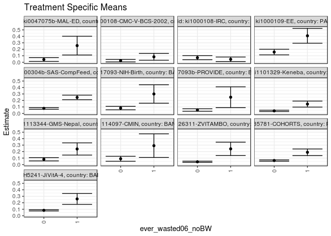

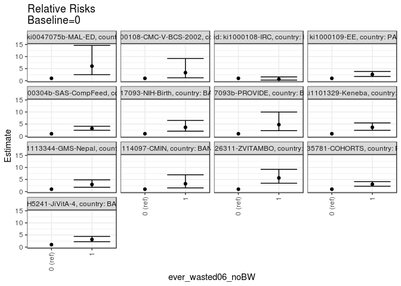

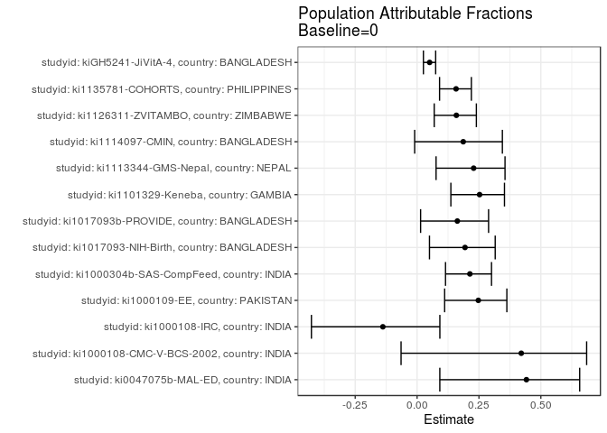

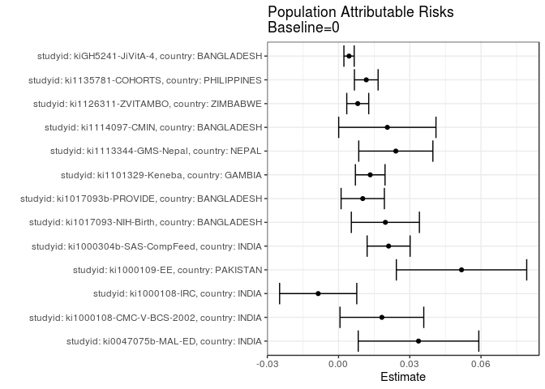

## Results Table

### Parameter: TSM

| studyid | country | intervention_level | baseline_level | estimate | ci_lower | ci_upper |
| --- | --- | --- | --- | --- | --- | --- |
| ki0047075b-MAL-ED | INDIA | 0 | NA | 0.0425532 | 0.0136352 | 0.0714712 |
| ki0047075b-MAL-ED | INDIA | 1 | NA | 0.2571429 | 0.1120220 | 0.4022637 |
| ki1000108-CMC-V-BCS-2002 | INDIA | 0 | NA | 0.0251046 | 0.0052421 | 0.0449671 |
| ki1000108-CMC-V-BCS-2002 | INDIA | 1 | NA | 0.0841121 | 0.0314456 | 0.1367787 |
| ki1000108-IRC | INDIA | 0 | NA | 0.0705882 | 0.0391100 | 0.1020664 |
| ki1000108-IRC | INDIA | 1 | NA | 0.0454545 | 0.0098742 | 0.0810349 |
| ki1000109-EE | PAKISTAN | 0 | NA | 0.1575092 | 0.1142344 | 0.2007839 |
| ki1000109-EE | PAKISTAN | 1 | NA | 0.4084507 | 0.2939478 | 0.5229536 |
| ki1000304b-SAS-CompFeed | INDIA | 0 | NA | 0.0777778 | 0.0647501 | 0.0908055 |
| ki1000304b-SAS-CompFeed | INDIA | 1 | NA | 0.2467532 | 0.2115921 | 0.2819144 |
| ki1017093-NIH-Birth | BANGLADESH | 0 | NA | 0.0820896 | 0.0552255 | 0.1089536 |
| ki1017093-NIH-Birth | BANGLADESH | 1 | NA | 0.3000000 | 0.1578262 | 0.4421738 |
| ki1017093b-PROVIDE | BANGLADESH | 0 | NA | 0.0524272 | 0.0331595 | 0.0716949 |
| ki1017093b-PROVIDE | BANGLADESH | 1 | NA | 0.2500000 | 0.0894649 | 0.4105351 |
| ki1101329-Keneba | GAMBIA | 0 | NA | 0.0394737 | 0.0296820 | 0.0492654 |
| ki1101329-Keneba | GAMBIA | 1 | NA | 0.1441441 | 0.0979279 | 0.1903604 |
| ki1113344-GMS-Nepal | NEPAL | 0 | NA | 0.0814480 | 0.0559241 | 0.1069718 |
| ki1113344-GMS-Nepal | NEPAL | 1 | NA | 0.2405063 | 0.1461704 | 0.3348422 |
| ki1114097-CMIN | BANGLADESH | 0 | NA | 0.0896226 | 0.0510906 | 0.1281547 |
| ki1114097-CMIN | BANGLADESH | 1 | NA | 0.2916667 | 0.1094338 | 0.4738996 |
| ki1126311-ZVITAMBO | ZIMBABWE | 0 | NA | 0.0428663 | 0.0328214 | 0.0529112 |
| ki1126311-ZVITAMBO | ZIMBABWE | 1 | NA | 0.2424242 | 0.1390028 | 0.3458457 |
| ki1135781-COHORTS | PHILIPPINES | 0 | NA | 0.0624442 | 0.0524267 | 0.0724618 |
| ki1135781-COHORTS | PHILIPPINES | 1 | NA | 0.1894273 | 0.1384425 | 0.2404121 |
| kiGH5241-JiVitA-4 | BANGLADESH | 0 | NA | 0.0829361 | 0.0730709 | 0.0928013 |
| kiGH5241-JiVitA-4 | BANGLADESH | 1 | NA | 0.2592593 | 0.1753180 | 0.3432005 |

### Parameter: E(Y)

| studyid | country | intervention_level | baseline_level | estimate | ci_lower | ci_upper |
| --- | --- | --- | --- | --- | --- | --- |
| ki0047075b-MAL-ED | INDIA | NA | NA | 0.0762332 | 0.0413252 | 0.1111412 |
| ki1000108-CMC-V-BCS-2002 | INDIA | NA | NA | 0.0433526 | 0.0218633 | 0.0648419 |
| ki1000108-IRC | INDIA | NA | NA | 0.0620155 | 0.0379551 | 0.0860759 |
| ki1000109-EE | PAKISTAN | NA | NA | 0.2093023 | 0.1662503 | 0.2523543 |
| ki1000304b-SAS-CompFeed | INDIA | NA | NA | 0.0988655 | 0.0888927 | 0.1088383 |
| ki1017093-NIH-Birth | BANGLADESH | NA | NA | 0.1018100 | 0.0735866 | 0.1300333 |
| ki1017093b-PROVIDE | BANGLADESH | NA | NA | 0.0626151 | 0.0422190 | 0.0830112 |
| ki1101329-Keneba | GAMBIA | NA | NA | 0.0528129 | 0.0423069 | 0.0633188 |
| ki1113344-GMS-Nepal | NEPAL | NA | NA | 0.1055662 | 0.0791553 | 0.1319771 |
| ki1114097-CMIN | BANGLADESH | NA | NA | 0.1101695 | 0.0701383 | 0.1502007 |
| ki1126311-ZVITAMBO | ZIMBABWE | NA | NA | 0.0509515 | 0.0402697 | 0.0616333 |
| ki1135781-COHORTS | PHILIPPINES | NA | NA | 0.0741191 | 0.0637839 | 0.0844543 |
| kiGH5241-JiVitA-4 | BANGLADESH | NA | NA | 0.0873606 | 0.0774748 | 0.0972464 |

### Parameter: RR

| studyid | country | intervention_level | baseline_level | estimate | ci_lower | ci_upper |
| --- | --- | --- | --- | --- | --- | --- |
| ki0047075b-MAL-ED | INDIA | 0 | 0 | 1.0000000 | 1.0000000 | 1.000000 |
| ki0047075b-MAL-ED | INDIA | 1 | 0 | 6.0428571 | 2.4980717 | 14.617724 |
| ki1000108-CMC-V-BCS-2002 | INDIA | 0 | 0 | 1.0000000 | 1.0000000 | 1.000000 |
| ki1000108-CMC-V-BCS-2002 | INDIA | 1 | 0 | 3.3504673 | 1.2215497 | 9.189664 |
| ki1000108-IRC | INDIA | 0 | 0 | 1.0000000 | 1.0000000 | 1.000000 |
| ki1000108-IRC | INDIA | 1 | 0 | 0.6439394 | 0.2615755 | 1.585233 |
| ki1000109-EE | PAKISTAN | 0 | 0 | 1.0000000 | 1.0000000 | 1.000000 |
| ki1000109-EE | PAKISTAN | 1 | 0 | 2.5931870 | 1.7513163 | 3.839751 |
| ki1000304b-SAS-CompFeed | INDIA | 0 | 0 | 1.0000000 | 1.0000000 | 1.000000 |
| ki1000304b-SAS-CompFeed | INDIA | 1 | 0 | 3.1725417 | 2.4505835 | 4.107194 |
| ki1017093-NIH-Birth | BANGLADESH | 0 | 0 | 1.0000000 | 1.0000000 | 1.000000 |
| ki1017093-NIH-Birth | BANGLADESH | 1 | 0 | 3.6545455 | 2.0545330 | 6.500603 |
| ki1017093b-PROVIDE | BANGLADESH | 0 | 0 | 1.0000000 | 1.0000000 | 1.000000 |
| ki1017093b-PROVIDE | BANGLADESH | 1 | 0 | 4.7685185 | 2.2754185 | 9.993225 |
| ki1101329-Keneba | GAMBIA | 0 | 0 | 1.0000000 | 1.0000000 | 1.000000 |
| ki1101329-Keneba | GAMBIA | 1 | 0 | 3.6516517 | 2.4346412 | 5.477012 |
| ki1113344-GMS-Nepal | NEPAL | 0 | 0 | 1.0000000 | 1.0000000 | 1.000000 |
| ki1113344-GMS-Nepal | NEPAL | 1 | 0 | 2.9528833 | 1.7873434 | 4.878480 |
| ki1114097-CMIN | BANGLADESH | 0 | 0 | 1.0000000 | 1.0000000 | 1.000000 |
| ki1114097-CMIN | BANGLADESH | 1 | 0 | 3.2543860 | 1.5243561 | 6.947870 |
| ki1126311-ZVITAMBO | ZIMBABWE | 0 | 0 | 1.0000000 | 1.0000000 | 1.000000 |
| ki1126311-ZVITAMBO | ZIMBABWE | 1 | 0 | 5.6553596 | 3.4759559 | 9.201236 |
| ki1135781-COHORTS | PHILIPPINES | 0 | 0 | 1.0000000 | 1.0000000 | 1.000000 |
| ki1135781-COHORTS | PHILIPPINES | 1 | 0 | 3.0335431 | 2.2175349 | 4.149826 |
| kiGH5241-JiVitA-4 | BANGLADESH | 0 | 0 | 1.0000000 | 1.0000000 | 1.000000 |
| kiGH5241-JiVitA-4 | BANGLADESH | 1 | 0 | 3.1260111 | 2.2187191 | 4.404318 |

### Parameter: PAR

| studyid | country | intervention_level | baseline_level | estimate | ci_lower | ci_upper |
| --- | --- | --- | --- | --- | --- | --- |
| ki0047075b-MAL-ED | INDIA | 0 | NA | 0.0336800 | 0.0082868 | 0.0590732 |
| ki1000108-CMC-V-BCS-2002 | INDIA | 0 | NA | 0.0182480 | 0.0006049 | 0.0358911 |
| ki1000108-IRC | INDIA | 0 | NA | -0.0085727 | -0.0248199 | 0.0076745 |
| ki1000109-EE | PAKISTAN | 0 | NA | 0.0517932 | 0.0243376 | 0.0792487 |
| ki1000304b-SAS-CompFeed | INDIA | 0 | NA | 0.0210877 | 0.0120336 | 0.0301418 |
| ki1017093-NIH-Birth | BANGLADESH | 0 | NA | 0.0197204 | 0.0053851 | 0.0340557 |
| ki1017093b-PROVIDE | BANGLADESH | 0 | NA | 0.0101879 | 0.0010751 | 0.0193008 |
| ki1101329-Keneba | GAMBIA | 0 | NA | 0.0133392 | 0.0070994 | 0.0195790 |
| ki1113344-GMS-Nepal | NEPAL | 0 | NA | 0.0241183 | 0.0085095 | 0.0397270 |
| ki1114097-CMIN | BANGLADESH | 0 | NA | 0.0205469 | 0.0000589 | 0.0410348 |
| ki1126311-ZVITAMBO | ZIMBABWE | 0 | NA | 0.0080852 | 0.0034618 | 0.0127087 |
| ki1135781-COHORTS | PHILIPPINES | 0 | NA | 0.0116748 | 0.0066832 | 0.0166665 |
| kiGH5241-JiVitA-4 | BANGLADESH | 0 | NA | 0.0044245 | 0.0022592 | 0.0065898 |

### Parameter: PAF

| studyid | country | intervention_level | baseline_level | estimate | ci_lower | ci_upper |
| --- | --- | --- | --- | --- | --- | --- |
| ki0047075b-MAL-ED | INDIA | 0 | NA | 0.4418023 | 0.0918735 | 0.6568928 |
| ki1000108-CMC-V-BCS-2002 | INDIA | 0 | NA | 0.4209205 | -0.0647081 | 0.6850470 |
| ki1000108-IRC | INDIA | 0 | NA | -0.1382353 | -0.4269134 | 0.0920405 |
| ki1000109-EE | PAKISTAN | 0 | NA | 0.2474562 | 0.1113637 | 0.3627065 |
| ki1000304b-SAS-CompFeed | INDIA | 0 | NA | 0.2132969 | 0.1149089 | 0.3007480 |
| ki1017093-NIH-Birth | BANGLADESH | 0 | NA | 0.1936982 | 0.0500755 | 0.3156060 |
| ki1017093b-PROVIDE | BANGLADESH | 0 | NA | 0.1627070 | 0.0142172 | 0.2888296 |
| ki1101329-Keneba | GAMBIA | 0 | NA | 0.2525744 | 0.1364829 | 0.3530585 |
| ki1113344-GMS-Nepal | NEPAL | 0 | NA | 0.2284657 | 0.0767232 | 0.3552689 |
| ki1114097-CMIN | BANGLADESH | 0 | NA | 0.1865022 | -0.0097774 | 0.3446291 |
| ki1126311-ZVITAMBO | ZIMBABWE | 0 | NA | 0.1586846 | 0.0692271 | 0.2395443 |
| ki1135781-COHORTS | PHILIPPINES | 0 | NA | 0.1575145 | 0.0908338 | 0.2193046 |
| kiGH5241-JiVitA-4 | BANGLADESH | 0 | NA | 0.0506460 | 0.0255537 | 0.0750921 |